# Law and Order: Denver Edition

Group Number: 14  
Section: 0502  
Date: 11/11/2022

# Section 1: Project Overview

Imagine walking through the pleasing streets of Denver, you would want to soak in as much of Denver's scenic beauty as possible! Would you ever want to worry about getting mugged or assaulted while on a stroll? No!

The Department of Police in Denver wouldn't want you to worry either, this is why they have ramped up efforts to protect Denver and all of its neighbourhood. They have hired Denver Mifflin, a consultancy group based out the city itself to help them protect its citizens and maintain the aura of safety Denver casts upon its citizens, tourists and beholders.

We are Denver Mifflin, and are determined to collaborate with the Department of Police to the highest degree. The government of Denver has provided us with a dataset that has recorded crimes since 2017 and the features of those crimes, for example: the neighborhood it occured it, offense type, offense catergory, etc. We, a team of 7 consultants are pouring over this dataset and are confidant that, at the end of our analysis, not only will we be able to help out the police, but also the kind citizens of Denver.

We begin by defining our end goals first, simply because we do not want to loose sight of what we are attempting to do here.

Research Questions:

Q1. Analyze the intervals between each occurrence of a given crime to identify the types of crimes that occur regularly.  
Goal: By determining crimes that occur almost on a day to day basis, we can help the Denver Police Department identify the types of crimes they need to address on priority. By reducing the instances of such crimes, the city of Denver will see a downward trend in the number of crimes committed each day. This will in turn bring down the yearly crime rate significantly.

Q2. For crimes that occur occasionally, we will try to identify patterns to understand on which particular days of the week such crimes occur.  
Goal : By analyzing the trends of crimes that occur occasionally and identifying the days on which such crimes typically take place, we would like to provide recommendations to the Denver Police Department on how to handle such crimes so that precautionary measures can be taken to prevent them in the future.

Q3. Derive insights on how the nature of the crime affects the time taken to report the crime  
Goal: We would like to analyze the time taken for specific crimes to be reported and incase of any delays, understand the underlying cause behind this delay in reporting time. Based on this, we can recommend the Denver Police Department to create public awareness campaigns and provide necessary protocols to encourage victims to report such crimes promptly.

Q4. Predicting the likelihood of a person being in an unsafe neighborhood in Denver based on the individual's coordinates.

Goal: We are attempting to map out potentially unsafe areas across Denver, classify them by likelihood of crime and send out basic safety measures based on an individual's co-ordinates. This will allow people to either steer clear of the shady areas of Denver or be cautious while in those areas. Achieving this will be a win-win scenario as the police will have the access to the same algorithm, so when a person in distress calls a simple check on their location will allow the police to prepare for kind of response they need to engage in, trying to diffuse the situation.

# Section 2: Milestones and Progress

- Project Proposal 10/14/2022
- Data Collection and Cleaning || 10/19/2022 || Task Lead - Sherman ||Task Completed  
  Since the dataset is taken from the https://www.denvergov.org/opendata/dataset/city-and-county-of-denver-crime the data is updated daily tried to explore the posibility of hitting the REST API for data collection which would help us avoid having to go to the website and try to downlaod teh csv file. However this was not possible because the data is sensitive and as a result there is no public token given out. Thus decided to use the CSV downlaoded file. Performed basic cleaning of the dataset.
- Weekly Project Huddle-1 || 10/20/2022 || Task Lead - Anwesha ||Task Completed  
  Most important task in this Project Huddle was explaining all columns of the dataset to each team member basically geeting an in depth knowledge of the dataset. Which was followed by a brainstorming session to understand the end goal and direction of the project. The main topic of disscussion was what level and type of Predictive Analytics and Machine Learning need to be included in the project and start preparing the first research question.
- Data Cleaning-2 || 10/26/2022 || Task Lead - Vishal ||Task Completed  
  Performend basic EDA on the dataset to get a basic overview of the entire dataset. In detail explaintion in the later part of this notebook.
- Weekly Project Huddle-2 || 10/27/2022 || Task Lead - Anwesha ||Task Completed  
  Take an update towards the thought process towards the first research question research and then start works towards implementation of the first research question.
- Data Analysis-1 || 11/02/2022 || Task Lead - Nishant ||Task Completed  
  With respect to the first business question looked at what statistic could best describe an answer to thsi question.  
  Explored all the options to make a final decision.
- Weekly Project Huddle-3 || 11/03/2022 || Task Lead - Anwesha ||Task Completed  
  Used this weekly meeting to come up with some more complex business questions. Place realistic goals keeping in mind the timelines available.
- Data Visulization-1 || 11/10/2022 || Task Lead - Madhulika ||Task Completed Compared the various visulizations available and tried to see which visulization would best bit the data discovered.Created Bar and line graphs to visualize the trends and occurrences of the crimes to derive observations and insights of the same
- Data Analysis-2 || 11/10/2022 || Task Lead - Shashank ||Task Not Completed This task was not completed because there was a change in business questions and as a result the work done had to be changed and hence ended being in complete.
- Weekly Project Huddle-4 || 11/10/2022 || Task Lead - Shashank ||Task Completed Spent the meeting building the project update report. Looking at the progress so far and decided how to move ahead.

### What resources will you need to accomplish your next steps? What is unclear in your plan?

We are still trying to figure out which predictive model will best suit our business needs as per the correlation we are trying to build. Further, figuring out if it will be possible to take coordinates from a user without having an interactive UI application. If this is not possible we would have to shift our focus from trying to predict the safety of a user from their coordinates to prediction based on their neighborhood. Another task is exploring the option of having interactive visulization specially because of the large volume of GIS data

# Section 3: Data Acquisition and Cleaning Code

Dataset aquired is the **crime** data set from https://www.denvergov.org/opendata/dataset/city-and-county-of-denver-crime the data is downloaded directly as a .csv file.

Permission for use :

According to the Open Data License present on the website You are free to copy, distribute, transmit and adapt the data in this catalog under an open license.

For further information refer to https://www.denvergov.org/opendata/termsofuse  
The data set currently has 377898 rows and 20 columns however the number of rows will be updated closer to the end of the project as the data gets updated everyday by the government of Denver

```python
# Loading librares to be used
import numpy as np
import pandas as pd
import seaborn as sn
import re
import matplotlib.pyplot as plt
```

```python
master_data = pd.read_csv("crime.csv",encoding="latin1") # reading the data into a dataframe
```

The column 'OFFENSE_TYPE_ID' has alot of abbrevated words for example 'assault' is represented as 'aslt' there are multiple examples of this. To maintain uniformity we replace all the abbrevated words by their full forms.  
To acheive this task we first build a dicitonary with the key as abbreavted word and value as that words full form Next we try to replace this in our main data frame

```python
replacement_dict = {'agg': 'aggravated', 'aslt' : 'assault', 'vin' : 'Vehicle Identification Number', 'poss' : 'possession', 'dv' :'domestic violence', 'burg' : 'burglary', 'busn' : 'business', 'resd' :'residential', '-w-' : 'with', 'mtr' : 'motor', 'veh' : 'vehicle', 'mfr': 'manufacture', 'deriv' : 'derivative','possess' :'possession', 'synth': 'synthetic', 'pos': 'possession','dev':'development','viol': 'violation', 'occ':'occupied','stln' : 'stolen', 'ftd':'Financial Transaction Device', 'unauth':'unauthorized','const': 'constant','bldg':'building', 'sex':'sexual','off': 'offender', 'asslt': 'assault','pot':'potential', 'rpt' : 'report','weap':'weapon','nsf':'non sufficient funds','inst': 'instrument'}
```

```python
master_data['OFFENSE_TYPE_ID'].replace(replacement_dict,regex=True,inplace=True) # Replacing values as
```

We first replace the capitalize the first Letters of each word in the column 'OFFENSE_TYPE_ID','OFFENSE_CATEGORY_ID' and 'NEIGHBORHOOD_ID' using the str.title() function.  
We then replace the '-' present in these columns with ''  
It helps to make the data more visually apealling when used as lables in graph plotting or other visulizations

```python
#  Removing all the '-' from the columns
master_data['OFFENSE_TYPE_ID'] = master_data['OFFENSE_TYPE_ID'].str.replace('-',' ',regex = True)
master_data['OFFENSE_CATEGORY_ID'] = master_data['OFFENSE_CATEGORY_ID'].str.replace('-',' ',regex = True)
master_data['NEIGHBORHOOD_ID'] = master_data['NEIGHBORHOOD_ID'].str.replace('-',' ',regex = True)
```

```python
# Capitalizing all the first words of the Column values
master_data['OFFENSE_TYPE_ID'] = master_data['OFFENSE_TYPE_ID'].str.title()
master_data['OFFENSE_CATEGORY_ID'] = master_data['OFFENSE_CATEGORY_ID'].str.title()
master_data['NEIGHBORHOOD_ID'] = master_data['NEIGHBORHOOD_ID'].str.title()
```

The column 'FIRST_OCCURRENCE_DATE' has its values in the date and time format we break this into two columns called 'FIRST_OCCURRENCE_DATE' and 'FIRST_OCCURRENCE_TIME'  
Similarly we break the values inthe column 'REPORTED_DATE' These values broken so that it is easier to see trends and calculate differences

```python
master_data[['FIRST_OCCURRENCE_DATE','FIRST_OCCURRENCE_TIME']]= master_data['FIRST_OCCURRENCE_DATE'].str.split(' ',1,expand=True) #Splitting the data
```

```python
master_data[['REPORTED_DATE','REPORTED_TIME']]= master_data['REPORTED_DATE'].str.split(' ',1,expand=True) #Splitting the data
```

Reordering the dataset to maintain easy readability

```python
master_data=master_data[['INCIDENT_ID','OFFENSE_ID','OFFENSE_CODE','OFFENSE_CODE_EXTENSION','OFFENSE_TYPE_ID','OFFENSE_CATEGORY_ID','FIRST_OCCURRENCE_DATE','FIRST_OCCURRENCE_TIME','LAST_OCCURRENCE_DATE','REPORTED_DATE','REPORTED_TIME','INCIDENT_ADDRESS','GEO_X','GEO_Y','GEO_LON','GEO_LAT','DISTRICT_ID','PRECINCT_ID','NEIGHBORHOOD_ID','IS_CRIME','IS_TRAFFIC','VICTIM_COUNT'
]]
```

```python
master_data.drop(columns=['LAST_OCCURRENCE_DATE'],inplace=True) # Dropping this column as it has no much use towards the analysis
```

We first try to find the average time taken for crimes to be reported as per category.  
In order to do this we first find the time difference between reported date and the first occurence date of the crime and then find the mean.

```python
data_for_analysis=master_data.copy() # Creating a copy so as to not ruin the master dataset
```

```python
#Extracting the year and month and storing them in seprate columns
data_for_analysis['CRIME_OCCURRENCE_YEAR'] = pd.DatetimeIndex(data_for_analysis['FIRST_OCCURRENCE_DATE']).year
data_for_analysis['CRIME_OCCURRENCE_MONTH'] = pd.DatetimeIndex(data_for_analysis['FIRST_OCCURRENCE_DATE']).month
```

```python
#Calculating time difference between the reported date and the first occurence date
data_for_analysis.loc[:, 'FIRST_OCCURRENCE_DATE'] = pd.to_datetime(data_for_analysis.loc[:, 'FIRST_OCCURRENCE_DATE'])
data_for_analysis.loc[:, 'REPORTED_DATE'] = pd.to_datetime(data_for_analysis.loc[:, 'REPORTED_DATE'])

data_for_analysis['TIME_DIFFERENCE'] = data_for_analysis['REPORTED_DATE'] - data_for_analysis['FIRST_OCCURRENCE_DATE']
```

```python
data_for_analysis['DAYS_DIFFERENCE'] = pd.to_timedelta(data_for_analysis.TIME_DIFFERENCE, errors='coerce').dt.days #building the time delta variable
```

```python
# Performing a group by function to categorize data by the average amount of time taken
values_as_per_group = data_for_analysis.groupby(by=data_for_analysis['OFFENSE_CATEGORY_ID'])['DAYS_DIFFERENCE'].agg('mean').sort_values(ascending=False)
```

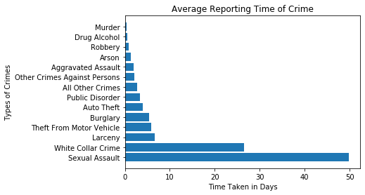

```python
plt.barh(values_as_per_group.index,values_as_per_group) #plotting the graph to understand how the values are distributed
plt.title('Average Reporting Time of Crime') # Setting the title of the plot
plt.xlabel("Time Taken in Days") # Setting the X- axis label
plt.ylabel("Types of Crimes") # Setting the Y- axis label
 # Setting the x-axis labels to be rotated so that it is visible.
```

Looking at the above graph we understand that it takes the longest to report Sexual Assault types of crimes.  
We perform a futher analysis to see what insights we gain

```python
sexual_assault_data = data_for_analysis[data_for_analysis['OFFENSE_CATEGORY_ID']=='Sexual Assault'] #Segregating data that has sexual assualt as the Offense Category ID
```

In order to predict a trend we try to try to see the number of cases of Sexual Assault Crimes each year with the help of a line graph

```python
crime_year_values = sexual_assault_data["CRIME_OCCURRENCE_YEAR"].to_numpy() #Creating a array of the values so that they can be used for plotting
```

```python
years,crime_counts=np.unique(crime_year_values,return_counts=True)# counting the unique values in the array
```

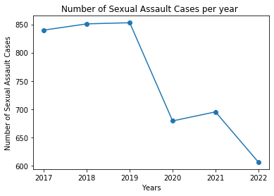

```python
plt.plot(years,crime_counts,marker='o')
plt.title('Number of Sexual Assault Cases per year ') # Setting the title of the plot
plt.xlabel("Years") # Setting the X- axis label
plt.ylabel("Number of Sexual Assault Cases") # Setting the Y- axis label
```

As seen above the number of cases per year reduced by a major amount from the year 2019 to 2020 could the COVID-19 pandemic have made an effect of the number of sexual assault cases being reported?

To gain further insights we try to understand what was the avearge reporting time of Sexual Assault cases per year.

```python
avg_sexual_assault_reporting_time = sexual_assault_data.groupby(by=sexual_assault_data['CRIME_OCCURRENCE_YEAR'])['DAYS_DIFFERENCE'].agg('mean').sort_values(ascending=False)
```

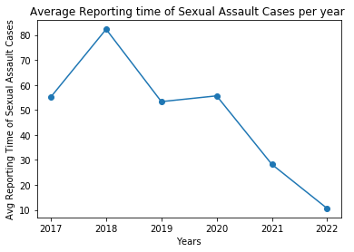

```python
avg_sexual_assault_reporting_time = avg_sexual_assault_reporting_time.sort_index()
plt.plot(avg_sexual_assault_reporting_time.index,avg_sexual_assault_reporting_time,marker='o')
plt.title('Average Reporting time of Sexual Assault Cases per year ') # Setting the title of the plot
plt.xlabel("Years") # Setting the X- axis label
plt.ylabel("Avg Reporting Time of Sexual Assault Cases") # Setting the Y- axis label
```

The intensity and Trauma inflicted by the crime affect the amount of time required to report the crime. Sometimes external forces try to subdue the crime from being reported to the Police. With the above analysis, we can clearly see that Sexualt Assualt on average, takes almost 50 days to get reported. Victims of sexual assault may not report the crime due to the following reasons:

- Stigma associated with the crime
- Emotional barriers faced by the victim
- Organisational cover-ups
- Unsuspected and known perpetrators  
  The Denver government has set up a initiative in their collaborative network like:
- Sexual Assault Response Team (“SART”)
- Denver Anti-Trafficking Alliance (DATA)
- Sexual Assault Interagency Council (“SAIC”)  
  Looking at the graphs over time we can say that these initiatives have been working and reducing the number of cases.However, we are no wehere close to the end goal of having least number of possible Sexual Assualt Cases.Thus, the Denver Government and Dnever Police must look even further into expanding their educating people about sexual violence and incorporate secure channels for easier reporting of such crimes.